# Week 7: Terrain Analysis

Yi Qiang  
Feb. 24, 2017

### Terrain Analysis

- The Earth Surface is not flat

[figure not shown]

### Terrain Analysis

- In addition to X, Y, there is Z (height)
- Also called 3D Analysis

[figure not shown]

### Why analyze terrain?

- Different types of terrain - different patterns of X, Y, and Z
- Formed by different processes - geological, hydrological, and volcanic
- [Human activities (anthropocene)](http://anthropocene.info/)

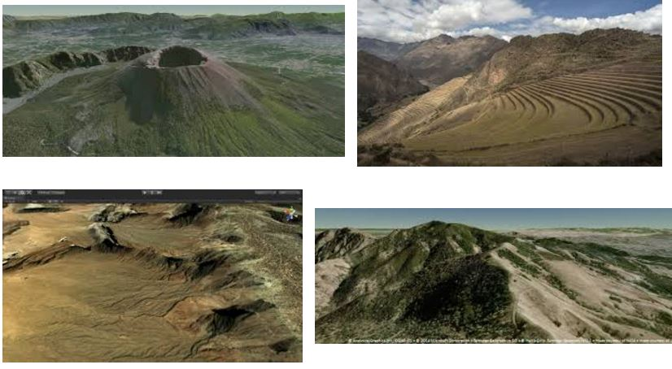

### Why analyze terrain?

Spatial metrics, such as distance, area and volumne

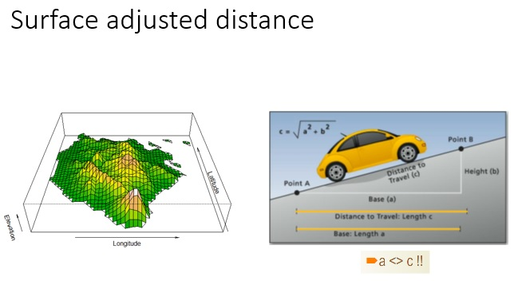

### Why analyze terrain?

Surface adjusted distance

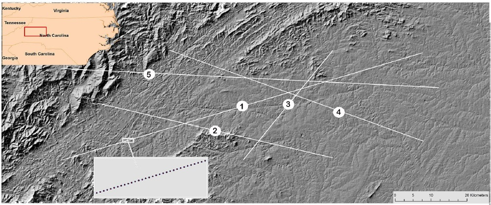

### Why analyze terrain?

hydrological modeling

[figure not shown]

### Why analyze terrain?

Landslide modeling

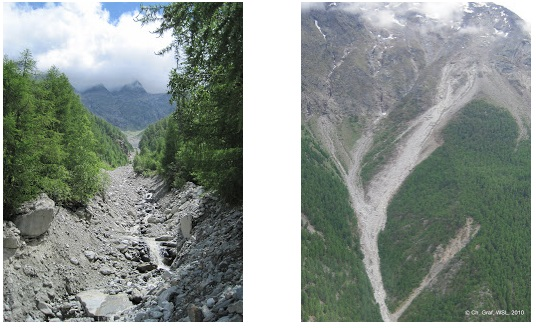

### Why analyze terrain?

Suitability modeling

[figure not shown]

### Modeling Surface in GIS

## Two Most Common Terrain Data Models:

- Digital Elevation Data (DEM) (Raster)
- Triangular Irregular Network (TIN) (Vector)

### Digital Elevation Model (DEM)

- DEM is basically a normal raster of elevation -it's called DEM because it is specific for a topographic surface
- A DEM is the simplest form to represent a topographic surface
- One of the most widely used data layers in many GIS applications
- The critical parameter is the resolution (or grid cell size)
- 1m resolution DEM for HI, 30m resolution for the US and 1km resolution for the globe are freely available

### Digital Elevation Model (DEM)

Essentially a raster of elevation (2D matrix)

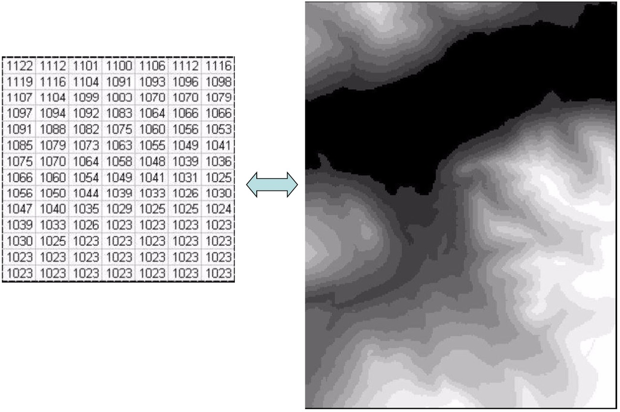

### Digital Elevation Model (DEM)

DEM in 3D

[figure not shown]

### Triangular Irregular Model

A vector model for 3D terrain

[figure not shown]

### Triangular Irregular Model

Delaunay Triangulation between sampling points

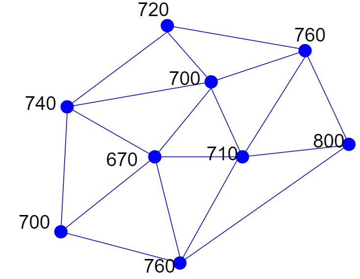

### Triangular Irregular Model

A facet of TIN in 3D

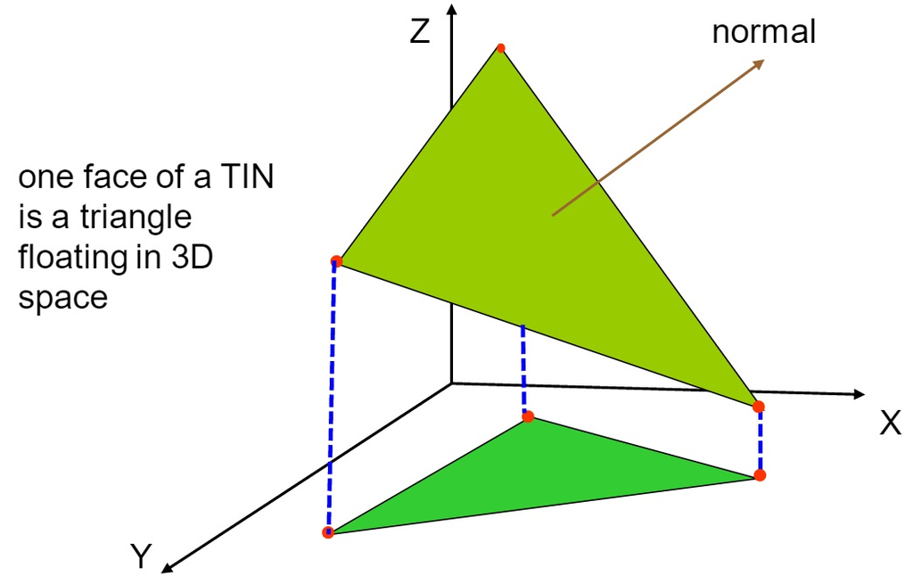

### Triangular Irregular Model

Resolution of TIN - number of triangles

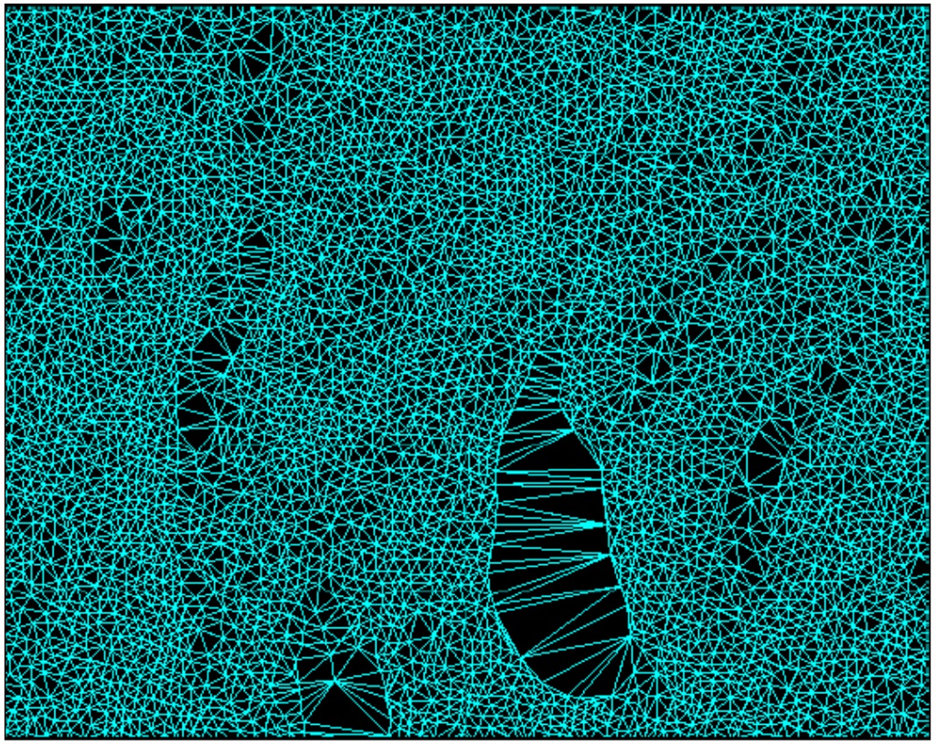

### Basic Terrain Analysis

- Surface-adjusted metrics (distance and area)
- Slope (Landslide susceptibility)
- Aspect (Solar insolation, vegetation)
- Profile (elevation change along a line)
- Viewshed (visibility)
- Hillshade (visualization)
- Area solar radiation
- *Flow path, watershed delination, flow accumulation (hydrology)*
- *Indices (e.g., terrain ruggedness)*

### Distance calculation in DEM (Pixel-to-pixel approach)

- Convert a vector line to a raster line
- The sum of actual run between every pair of adjacent pixels

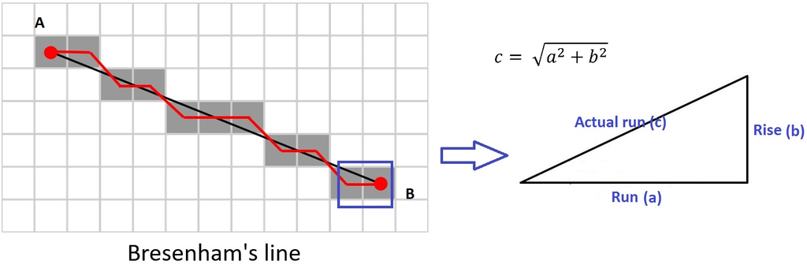

### Distance calculation in DEM (Sampling approach)

- Define sampling points along a transect
- The sum of distance between each pair of points

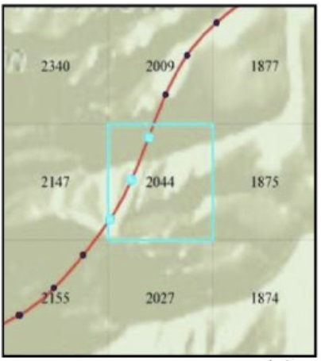

### Distance calculation in TIN

- Define a number of sampling points along a transect
- The elevation of a point is estimated from the triangle it is located in or the surrounding triangles
- The sum of distance between each pair of sampling points

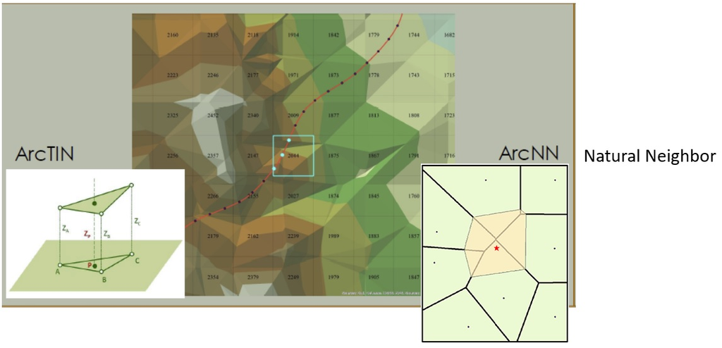

### No guidelines of distance calculation

- ~ 10 different measurement approaches
- Caculation accuracy = f(DEM/TIN resolution, landscape, interpolation method, sampling size)
- Trade-offs between accuracy and data size, accuracy and computation time.

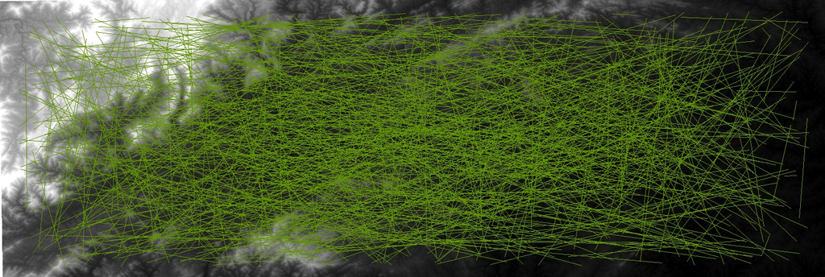

### Area caculation

Surface adjusted area is the total area of all the triangular facets

[figure not shown]

### Slope Calculation

- Angle of the slope (degree)
- Ratio of the slope (percentage)

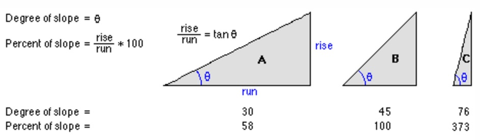

### Calculate slope in DEM

- In DEM, maximum rate of change in value from that cell to its neighbors.

[figure not shown]

### Slope calculation in ArcGIS

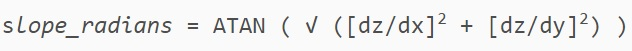

### Calculate slope in DEM

Elevation to Slope

[figure not shown]

### Aspect

- The direction of the slope

[figure not shown]

### Profile

Most GIS packages provide tools for examining the profile of a surface along a selected straight line or series of straight line segments (polyline).

[figure not shown]

### Profile

Profile along multiple straight transects

[figure not shown]

### Profile

- Profile of a path/route

[figure not shown]

### Viewshed

- Areas visible to a set of observer features.
- Viewshed tool in ArcGIS

[figure not shown]

### Viewshed

- Listening Posts/Observation Posts (LP/LO)
- Weapons placement
- Antenna placement for radar, radios, or cell phones
- Special surveillance equipment placement

[figure not shown]

### Hillshade

- Hypothetical illumination of a surface by determining illumination values for each cell in a raster
- Enhance the visualization of a surface for analysis or graphical display
- Parameters: altitude and azimuth

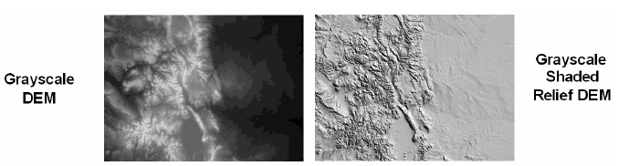

### Altitude (Hillshade)

- The altitude is the angle of the illumination source (e.g. the sun) above the horizon.
- The units are in degrees, from 0 (on the horizon) to 90 (overhead). The default is 45 degrees.

[figure not shown]

### Hillshade (Hillshade)

- Azimuth is the angular direction of the sun, measured from north in clockwise degrees from 0 to 360.
- An azimuth of 90 degrees is east. The default azimuth is 315 degrees (NW).
- Why default azimuth is 315 (NW), given most people are living in the North Hemisphere where the Sun azimuth is South?

[figure not shown]

### Hillshade

## Sink or hill?

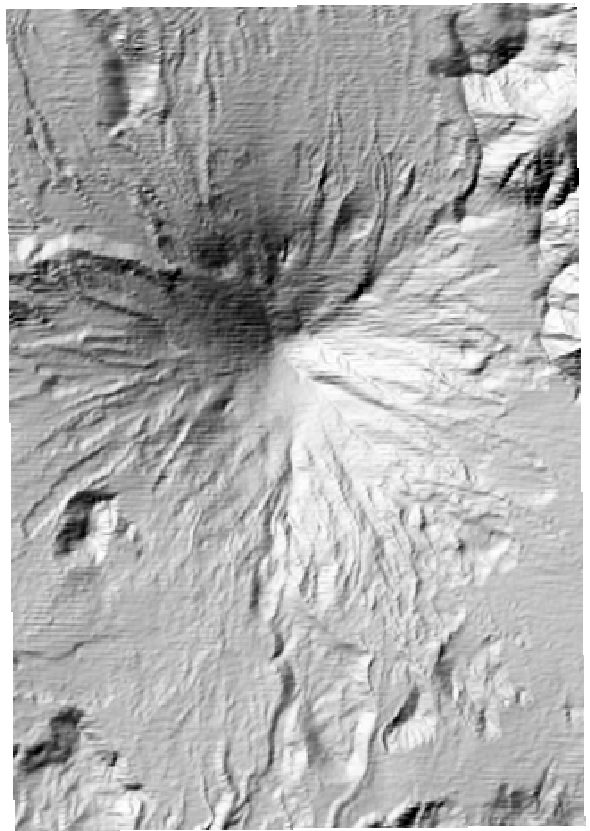

### Hillshade

## Sink or hill?

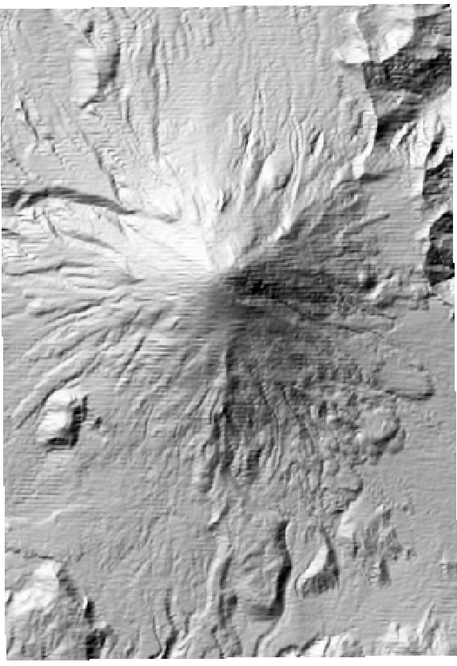

### Hillshade

Original DEM - hill

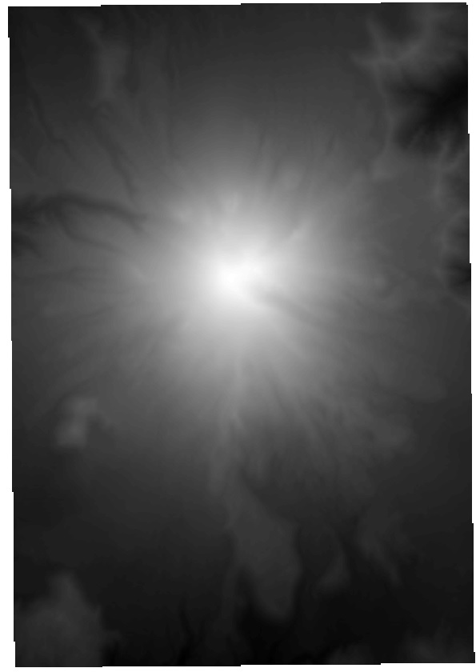

### Hillshade

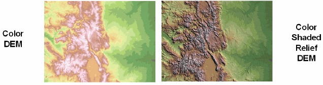

### Solar Radiation Analysis

Cumulative solar radiation in a day (Area Solar Radiation tool in ArcGIS)

[figure not shown]

Solar Radiation: Summer Solstice

[figure not shown]

Solar Radiation: Winter Solstice

[figure not shown]

### Anouncement

Change of topics: Topic 5: Spatial Interpolation -> Hazard risk and vulnerability assessment Topic 6: Advanced spatial modeling -> Web mapping Next class -> Project discussion

### Lab 4 Assignment (Terrain analysis)

Due date March 17

https://github.com/qiang-yi/GEOG489/blob/master/labs/lab4_terrain_analysis.docx